# Predicting Financial Market Returns and Volatility with ARIMA, Deep Learning (LSTM/GRU), and GARCH Models (Part 1 ARIMA and GARCH)

# The context:

Financial markets are inherently volatile, and predicting both returns and risk is essential for investors, asset managers, and algorithmic trading systems. Relying solely on historical averages or manual intuition often leads to poor timing and suboptimal decisions—buying at the peak, selling during drawdowns, or misjudging market uncertainty. Moreover, ignoring risk leads to overexposure, while underestimating returns causes missed opportunities.

Traditional financial models may capture trends but fail to adapt quickly to changing dynamics. At the same time, modern deep learning approaches are powerful but often lack interpretability and risk control. A hybrid solution that integrates time series forecasting (ARIMA, LSTM, GRU) with volatility modeling (GARCH) can provide a more complete picture—anticipating both where the market might go and how risky that move could be.

By automating this dual-forecasting system, investors can make more informed, data-driven decisions, allocate capital more efficiently, and adjust exposure dynamically. This approach not only improves returns but also protects capital by managing volatility—a critical factor in real-world trading and portfolio optimization.

# Key Questions

What factors drive the movement of the asset’s returns?

How volatile is the asset over time, and are there identifiable volatility clusters?

Is the time series stationary, and how does that affect model choice and performance?

Which model—ARIMA, LSTM, or GRU—best captures the return dynamics?

Can we accurately forecast volatility, and how does it improve decision-making?

How should predictions of return and volatility be combined to drive investment decisions?

What rules or thresholds should be used to trigger buy/sell/hold actions?

What is the trade-off between maximizing return and controlling risk?

How does the strategy perform when applied to real or simulated trading?

How robust are the models across different market conditions?

What practical recommendations can be derived for investors based on the forecasts?

# The Problem Definition

The problem we are trying to solve is to predict future asset returns and estimate their associated volatility using historical market data. By building data-driven models that capture both expected value (return) and risk (volatility), we aim to support more informed and adaptive investment decisions.

The goal is to help investors, analysts, and trading systems better navigate uncertainty in financial markets — maximizing returns while controlling risk exposure, and ultimately improving performance in real-world trading environments.

This is a supervised time series forecasting problem, where we aim to:

- Predict future returns using models such as ARIMA, LSTM, and GRU.
- Forecast time-varying volatility using GARCH models to capture risk dynamics.
- Combine both predictions to guide operational decisions like buying, selling, or adjusting position sizes.
- Evaluate the strategy through backtesting to assess robustness, profitability, and risk metrics.

## Data Description

This dataset serves as the basis for modeling financial return prediction and volatility forecasting. The target variables are:

Daily Log Return: A continuous variable representing the percentage change in adjusted closing price.

Volatility: A measure of market risk, estimated through statistical models like GARCH.

Additional features will be engineered from the price series to improve model performance, including technical indicators and lagged values for use in deep learning models.

```python
# Core data handling and visualization
import pandas as pd
import numpy as np
import matplotlib.pyplot as plt
import seaborn as sns
!pip install arch


import yfinance as yf

import warnings
warnings.filterwarnings("ignore")

pd.set_option("display.max_columns", None)
pd.set_option("display.max_rows", 200)

# Time series and econometric modeling
import statsmodels.api as sm            # ARIMA, diagnostics, time series tools
import statsmodels.tsa.api as tsa       # Specific time series methods
from arch import arch_model             # GARCH models for volatility modeling

# Machine learning preprocessing and splitting
from sklearn.preprocessing import StandardScaler
from sklearn.model_selection import train_test_split

# Deep learning for LSTM and GRU
import tensorflow as tf
from tensorflow.keras.models import Sequential
from tensorflow.keras.layers import LSTM, GRU, Dense, Dropout
from tensorflow.keras.callbacks import EarlyStopping
!pip install pmdarima
from statsmodels.tsa.arima.model import ARIMA

# Metrics for regression and forecasting evaluation
from sklearn.metrics import mean_squared_error, mean_absolute_error
```

```python
# Define the ticker and period
ticker = "AAPL"
start_date = "2015-01-01"
end_date = "2024-12-31"

# Download the data
data = yf.download(ticker, start=start_date, end=end_date)

# Show the first rows and the column names
print(data.head())
print("\nColumns in the dataset:")
for col in data.columns:
    print(f"- {col}")
```

```
[*********************100%***********************]  1 of 1 completed
```

```
Price           Close       High        Low       Open     Volume
Ticker           AAPL       AAPL       AAPL       AAPL       AAPL
Date
2015-01-02  24.288578  24.757332  23.848704  24.746224  212818400
2015-01-05  23.604328  24.137509  23.417716  24.057531  257142000
2015-01-06  23.606554  23.866479  23.244435  23.668758  263188400
2015-01-07  23.937574  24.037545  23.704307  23.815387  160423600
2015-01-08  24.857306  24.915067  24.148620  24.266365  237458000

Columns in the dataset:
- ('Close', 'AAPL')
- ('High', 'AAPL')
- ('Low', 'AAPL')
- ('Open', 'AAPL')
- ('Volume', 'AAPL')
```

Data Overview

- Reviwng the dataset
- Understanding the shape of the dataset
- Checking the data types
- Checking for missing values
- Checking for duplicated values

```python
# View the first 5 rows of the dataset
data.head()# View the first 5 rows of the dataset
```

| Price Ticker Date | Close AAPL | High AAPL | Low AAPL | Open AAPL | Volume AAPL |
| --- | --- | --- | --- | --- | --- |
| 2015-01-02 | 24.288578 | 24.757332 | 23.848704 | 24.746224 | 212818400 |
| 2015-01-05 | 23.604328 | 24.137509 | 23.417716 | 24.057531 | 257142000 |
| 2015-01-06 | 23.606554 | 23.866479 | 23.244435 | 23.668758 | 263188400 |
| 2015-01-07 | 23.937574 | 24.037545 | 23.704307 | 23.815387 | 160423600 |
| 2015-01-08 | 24.857306 | 24.915067 | 24.148620 | 24.266365 | 237458000 |

```python
# Understand the shape of the data
data.shape
```

```
(2515, 5)
```

```python
# Checking the info of the data
data.info()
```

```
<class 'pandas.core.frame.DataFrame'>
DatetimeIndex: 2515 entries, 2015-01-02 to 2024-12-30
Data columns (total 5 columns):
 #   Column          Non-Null Count  Dtype
---  ------          --------------  -----
 0   (Close, AAPL)   2515 non-null   float64
 1   (High, AAPL)    2515 non-null   float64
 2   (Low, AAPL)     2515 non-null   float64
 3   (Open, AAPL)    2515 non-null   float64
 4   (Volume, AAPL)  2515 non-null   int64
dtypes: float64(4), int64(1)
memory usage: 117.9 KB
```

Findings:

- The dataset contains no null values, indicating clean and complete daily trading data for the selected period.
- The columns Close, High, Low, and Open are of type float64, which is consistent with price values that can have decimals.
- The Volume column is of type int64, which is expected since shares traded are counted as whole units—fractional shares are not represented here.

```python
# Checking the descriptive statistics of the columns
data.describe().T
```

| Price | Ticker | count | mean | std | min | 25% | 50% | 75% | max |
| --- | --- | --- | --- | --- | --- | --- | --- | --- | --- |
| Close | AAPL | 2515.0 | 9.399461e+01 | 6.551848e+01 | 2.064746e+01 | 3.527745e+01 | 6.450931e+01 | 1.505360e+02 | 2.583967e+02 |
| High | AAPL | 2515.0 | 9.490727e+01 | 6.611210e+01 | 2.095143e+01 | 3.568195e+01 | 6.485945e+01 | 1.522673e+02 | 2.594741e+02 |
| Low | AAPL | 2515.0 | 9.297880e+01 | 6.482941e+01 | 2.044862e+01 | 3.491755e+01 | 6.369887e+01 | 1.485159e+02 | 2.570100e+02 |
| Open | AAPL | 2515.0 | 9.390677e+01 | 6.543598e+01 | 2.056975e+01 | 3.530843e+01 | 6.426709e+01 | 1.503178e+02 | 2.575687e+02 |
| Volume | AAPL | 2515.0 | 1.171176e+08 | 6.839566e+07 | 2.323470e+07 | 7.108210e+07 | 1.003845e+08 | 1.426222e+08 | 6.488252e+08 |

# Summary Statistics

As part of the initial exploratory data analysis, we examined the basic statistics of the historical stock prices and trading volumes for Apple (AAPL) over the selected period. This step helps us understand the range, central tendency, and variability of the key financial variables that will feed into our modeling.

The price variables (Open, High, Low, Close) show substantial variability, reflecting typical market fluctuations and trends over nearly a decade. The average closing price around 94 with a wide range from about 20 to over 250 indicates periods of significant growth and volatility.

Trading volume also exhibits considerable variation, with daily shares traded ranging from tens of millions to over 600 million. This variability in volume may influence liquidity and volatility dynamics and will be important when engineering features for predictive modeling.

Understanding these basic characteristics is crucial to inform subsequent data preprocessing, feature engineering, and model selection steps.

# Exploratory Data Analysis (EDA) and Visualization

EDA is a crucial step in any data-driven project. It allows us to investigate, understand, and prepare the data before applying predictive models. By analyzing the dataset thoroughly, we can uncover patterns, detect anomalies, and generate insights that inform the modeling process.

For this project focused on stock price prediction and volatility modeling, here are some guiding questions to frame our analysis:

- What is the overall range and distribution of the stock prices (Open, High, Low, Close)?
- How does the trading volume vary over time, and are there periods of unusually high or low volume?
- Are there any noticeable trends or seasonality in the price and volume data?
- How do the different price variables correlate with each other?
- What is the distribution of returns and volatility over the period?
- Are there any outliers or anomalies in the price or volume data?
- How stable is the volatility over different time windows?
- Can we identify clusters or regimes in the data that might indicate different market conditions?

By addressing these questions through visualization and statistical analysis, we can build a strong foundation for the subsequent feature engineering and modeling phases.

```python
# Calculate Log Returns
data['Log_Returns'] = np.log(data['Close'] / data['Close'].shift(1))
data.dropna(inplace=True)
```

Logarithmic returns, or log returns, measure the continuous compounded return of a stock price from one time point to the next. They are calculated as the natural logarithm of the ratio of consecutive prices:

Why use log returns?

They are time additive, meaning returns over multiple periods can be summed directly.

They handle percentage changes symmetrically for price increases and decreases.

Log returns approximate simple returns for small changes but behave better mathematically for many financial models.

In our analysis, calculating log returns allows us to better understand the true underlying changes in stock price over time and is essential for modeling volatility and risk.

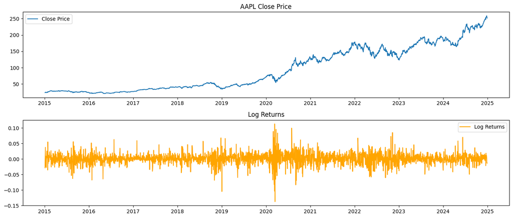

```python
#Price & Return Plot
plt.figure(figsize=(14, 6))
plt.subplot(2,1,1)
plt.plot(data['Close'], label="Close Price")
plt.title("AAPL Close Price")
plt.legend()

plt.subplot(2,1,2)
plt.plot(data['Log_Returns'], color='orange', label="Log Returns")
plt.title("Log Returns")
plt.legend()
plt.tight_layout()
plt.show()
```

1. The price series exhibits a long-term upward trend, meaning that since 2019, the price has generally been increasing, although with some intermittent declines. Before applying any models, it is essential to analyze whether the series is stationary or not.
2. The log returns plot reveals volatility, which is defined as the conditional variance of the series. Even if the series is stationary, its variance may exhibit short-term fluctuations. Some important properties of volatility are:
- **Volatility Clustering:** Volatility tends to appear in clusters over certain periods, meaning high volatility is often followed by more high volatility, and low volatility tends to follow low volatility. Large changes in volatility tend to be followed by large changes, while small changes tend to be followed by small changes.
- **Mean Reversion:** Due to volatility clustering, periods of high volatility are eventually followed by periods of normal or lower volatility, and vice versa. Volatility tends to revert to a normal or average level over time. Long-term forecasts of volatility will converge to this normal level, regardless of when the forecast is made.
- **Volatility Asymmetry:** Volatility behaves differently in response to positive and negative shocks. It does not react symmetrically to large increases versus decreases in asset prices. Many models assume that conditional variance is affected symmetrically by shocks (for example, ARCH(p) models depend on squared lagged innovations), but this ignores the asymmetry known as the leverage effect, which has been modeled by variants such as EGARCH.
- **Influence of Exogenous Variables:** Asset prices do not evolve independently of broader market conditions. Therefore, there are often external variables containing relevant information that influence the volatility of the series.
- **Probability Distribution:** The distribution of returns typically exhibits heavy tails and excess kurtosis, indicating a higher likelihood of extreme events than a normal distribution would predict.

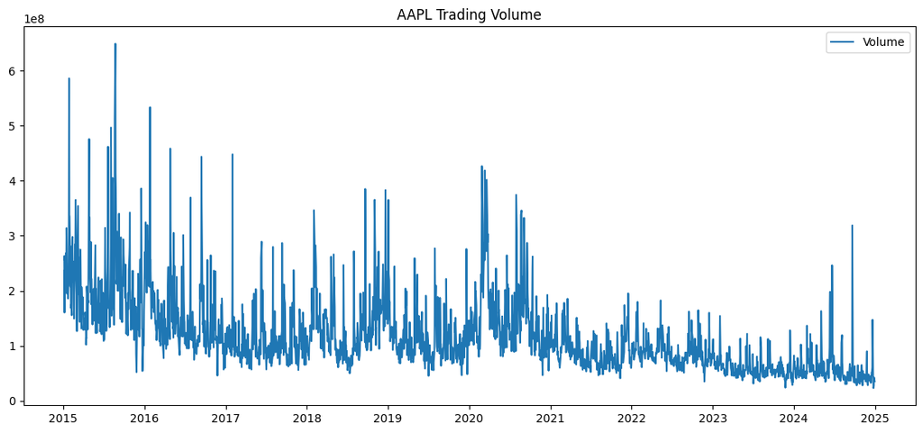

```python
#Trading Volume
plt.figure(figsize=(14, 6))
plt.plot(data['Volume'], label="Volume")
plt.title("AAPL Trading Volume")
plt.legend()
```

Trading Volume Analysis:

The trading volume appears to exhibit a downward trend over the observed period. Although there are noticeable peaks in certain months—possibly aligned with earnings reports, product announcements, or macroeconomic events—these peaks tend to diminish in magnitude over time. This suggests a gradual decline in overall market activity or investor interest in the stock throughout the years.

# Splitting the dataset

We'll consider the data from the last 12 months as the test data and the remaining data as the train data.

```python
# Approximate number of trading days in a year
n_test_days = 252

# Split the data
df_train = data.iloc[:-n_test_days]
df_test = data.iloc[-n_test_days:]

print("Train data:")
print(df_train.tail())

print("\nTest data:")
print(df_test.head())
```

```
Train data:
Price            Close        High         Low        Open    Volume  \
Ticker            AAPL        AAPL        AAPL        AAPL      AAPL
Date
2023-12-21  193.264679  195.647240  192.093265  194.674369  46482500
2023-12-22  192.192551  193.989390  191.567126  193.761051  37122800
2023-12-26  191.646561  192.480450  191.428159  192.202487  28919300
2023-12-27  191.745834  192.093296  189.700813  191.090644  48087700
2023-12-28  192.172699  193.244849  191.765676  192.728625  34049900

Price      Log_Returns
Ticker
Date
2023-12-21   -0.000770
2023-12-22   -0.005563
2023-12-26   -0.002845
2023-12-27    0.000518
2023-12-28    0.002224

Test data:
Price            Close        High         Low        Open    Volume  \
Ticker            AAPL        AAPL        AAPL        AAPL      AAPL
Date
2023-12-29  191.130325  192.986726  190.336138  192.490361  42628800
2024-01-02  184.290421  187.070068  182.553143  185.789438  82488700
2024-01-03  182.910507  184.528662  182.096461  182.880727  58414500
2024-01-04  180.587540  181.758954  179.565029  180.825785  71983600
2024-01-05  179.862823  181.431339  178.860172  180.666948  62303300

Price      Log_Returns
Ticker
Date
2023-12-29   -0.005439
2024-01-02   -0.036443
2024-01-03   -0.007516
2024-01-04   -0.012781
2024-01-05   -0.004021
```

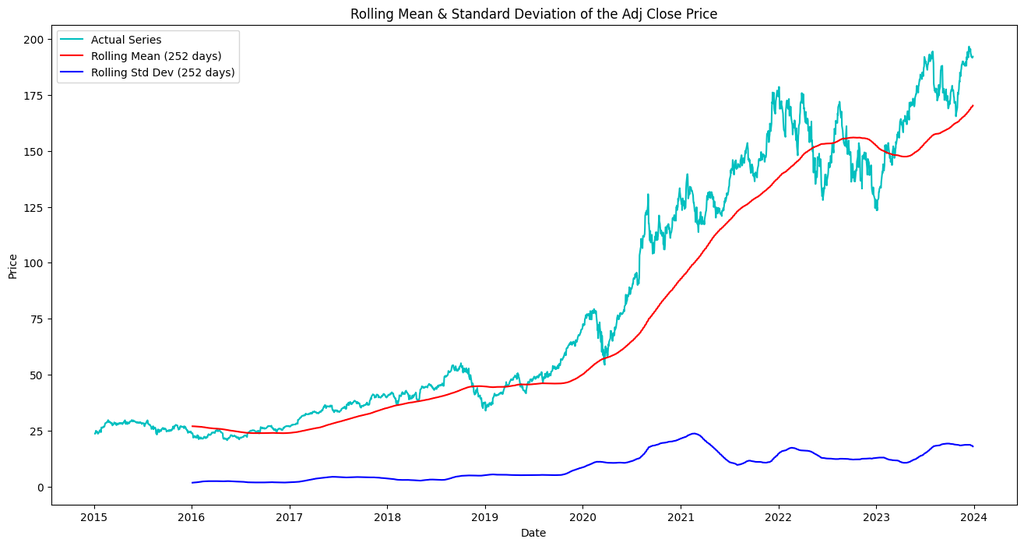

```python
# Calculate rolling statistics for the 'Adj Close' column
rolmean = df_train['Close'].rolling(window=252).mean()
rolstd = df_train['Close'].rolling(window=252).std()

# Plot the rolling statistics
plt.figure(figsize=(16, 8))

plt.plot(df_train['Close'], color='c', label='Actual Series')
plt.plot(rolmean, color='red', label='Rolling Mean (252 days)')
plt.plot(rolstd, color='blue', label='Rolling Std Dev (252 days)')

plt.title('Rolling Mean & Standard Deviation of the Adj Close Price')
plt.xlabel('Date')
plt.ylabel('Price')
plt.legend()
plt.show()
```

# Observations:

1. We can see that there is an upward trend in the series.
2. We can confirm that the series is not stationary.
3. We can also use the Augmented Dickey-Fuller (ADF) Test to verify if the series is stationary or not. The null and alternate hypotheses for the ADF Test are defined as:
- Null hypothesis: The Time Series is non-stationary
- Alternative hypothesis: The Time Series is stationary

```python
# Define a function to use adfuller test
def adfuller(data, column):

  #Importing adfuller using statsmodels
    from statsmodels.tsa.stattools import adfuller

    print('Dickey-Fuller Test: ')

    adftest = adfuller(data[column])

    adfoutput = pd.Series(adftest[0:4], index = ['Test Statistic', 'p-value', 'Lags Used', 'No. of Observations'])

    for key, value in adftest[4].items():
        adfoutput['Critical Value (%s)'%key] = value

    print(adfoutput)
```

```python
 adfuller(df_train, 'Close')
```

```
Dickey-Fuller Test:
Test Statistic             0.263082
p-value                    0.975586
Lags Used                 18.000000
No. of Observations     2243.000000
Critical Value (1%)       -3.433269
Critical Value (5%)       -2.862829
Critical Value (10%)      -2.567456
dtype: float64
```

# Observations:

From the above test, we can see that the p-value is around 0.975, i.e., > 0.05 (for 95% confidence intervals) therefore, we fail to reject the null hypothesis. Hence, we can confirm that the series is non-stationary.

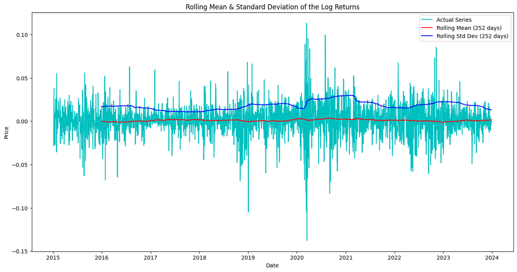

```python
# Calculate rolling statistics for the 'Log Return' column
# The Log returns often remove trend and stabilize variance, making the series more suitable for modeling
rolmean = df_train['Log_Returns'].rolling(window=252).mean()
rolstd = df_train['Log_Returns'].rolling(window=252).std()

# Plot the rolling statistics
plt.figure(figsize=(16, 8))

plt.plot(df_train['Log_Returns'], color='c', label='Actual Series')
plt.plot(rolmean, color='red', label='Rolling Mean (252 days)')
plt.plot(rolstd, color='blue', label='Rolling Std Dev (252 days)')

plt.title('Rolling Mean & Standard Deviation of the Log Returns')
plt.xlabel('Date')
plt.ylabel('Price')
plt.legend()
plt.show()
```

```python
adfuller(df_train,'Log_Returns')
```

```
Dickey-Fuller Test:
Test Statistic         -1.471654e+01
p-value                 2.794250e-27
Lags Used               8.000000e+00
No. of Observations     2.253000e+03
Critical Value (1%)    -3.433256e+00
Critical Value (5%)    -2.862824e+00
Critical Value (10%)   -2.567453e+00
dtype: float64
```

Since the test statistic is much less than the critical values and the p-value is tiny, we reject the null hypothesis of non-stationarity.

- Conclusion: Log returns are stationary, so they are appropriate for modeling, volatility analysis, and forecasting.

# Decomposing the time series components into Trend, Seasonality, and Residual

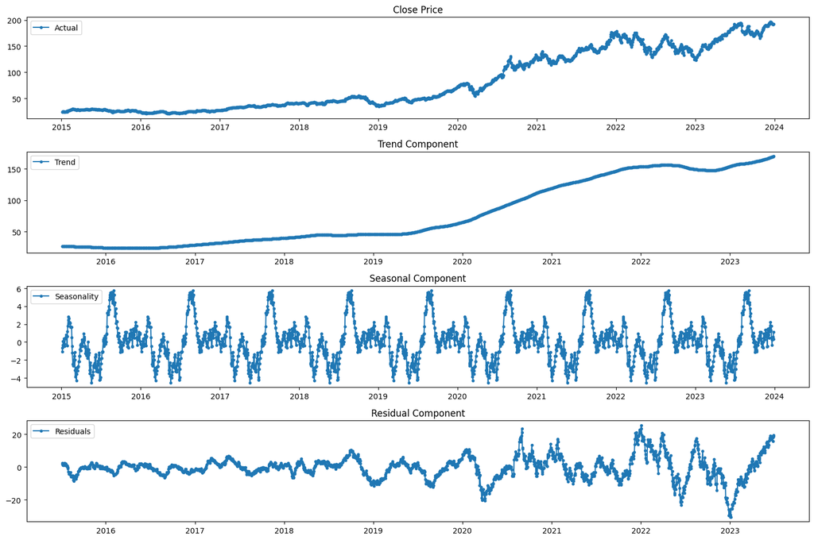

```python
from statsmodels.tsa.seasonal import seasonal_decompose
import matplotlib.pyplot as plt

# Decompose the 'Close' price series
decomp = seasonal_decompose(df_train['Close'], model='additive', period=252)  # Using yearly seasonality approx.

trend = decomp.trend
seasonal = decomp.seasonal
residual = decomp.resid

plt.figure(figsize=(15, 10))

plt.subplot(411)
plt.plot(df_train['Close'], label='Actual', marker='.')
plt.legend(loc='upper left')
plt.title('Close Price')

plt.subplot(412)
plt.plot(trend, label='Trend', marker='.')
plt.legend(loc='upper left')
plt.title('Trend Component')

plt.subplot(413)
plt.plot(seasonal, label='Seasonality', marker='.')
plt.legend(loc='upper left')
plt.title('Seasonal Component')

plt.subplot(414)
plt.plot(residual, label='Residuals', marker='.')
plt.legend(loc='upper left')
plt.title('Residual Component')

plt.tight_layout()
plt.show()
```

# ACF and PACF plots

Plotting the auto-correlation function and partial auto-correlation function to get p and q values for ARIMA models.

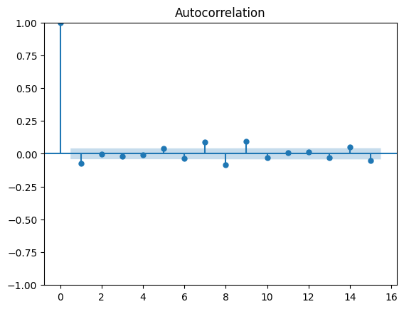

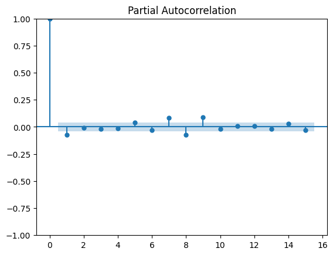

```python
from statsmodels.graphics.tsaplots import plot_acf, plot_pacf

plt.figure(figsize = (16, 8))

plot_acf(df_train['Log_Returns'], lags = 15)

plt.show()

plot_pacf(df_train['Log_Returns'], lags = 15)

plt.show()
```

From the graphs we can get the p and q coefficient for the ARIMA model. In this case p=9 and q=9

**Get the sqaured returns to model volatility**

```python
# Ensure your train set includes log returns
log_returns = df_train['Log_Returns']
squared_returns = log_returns ** 2
```

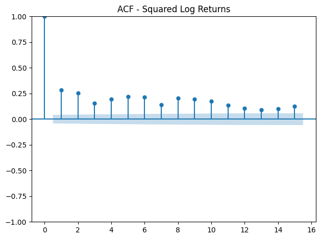

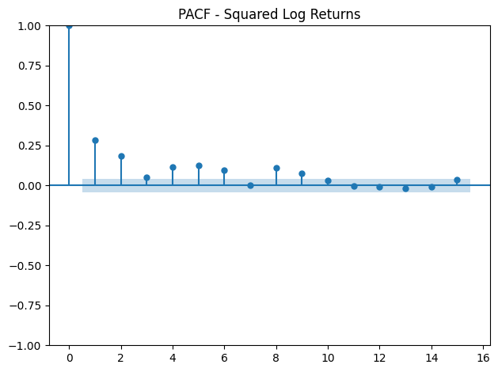

```python
# Plot ACF and PACF of Squared Log Returns
plt.figure(figsize=(14, 6))
plot_acf(squared_returns, lags=15, title="ACF - Squared Log Returns")
plt.tight_layout()
plt.show()

plt.figure(figsize=(14, 6))
plot_pacf(squared_returns, lags=15, title="PACF - Squared Log Returns")
plt.tight_layout()
plt.show()
```

For modeling volatily we will use p=1 and q=1

# Normality Tests

In financial time series:

Most models (like ARIMA) assume normally distributed residuals.

However, returns often have fat tails (leptokurtosis), violating this assumption.

Testing normality helps justify the use of models like GARCH or those with heavy-tailed distributions (e.g., t-distribution).

```python
from scipy.stats import shapiro, jarque_bera
import numpy as np

# Get the log returns from training data
log_returns = df_train['Log_Returns'].dropna()

# Shapiro-Wilk Test
shapiro_stat, shapiro_p = shapiro(log_returns)
print("Shapiro-Wilk Test:")
print(f"  Statistic = {shapiro_stat:.4f}")
print(f"  p-value   = {shapiro_p:.4f}\n")

# Jarque-Bera Test
jb_stat, jb_p = jarque_bera(log_returns)
print("Jarque-Bera Test:")
print(f"  Statistic = {jb_stat:.4f}")
print(f"  p-value   = {jb_p:.4f}")
```

```
Shapiro-Wilk Test:
  Statistic = 0.9416
  p-value   = 0.0000

Jarque-Bera Test:
  Statistic = 2765.9077
  p-value   = 0.0000
```

The p value is less than 0.05, we should reject the null hypotesis. Meaning the residual are not normally distributed

# ARCH Test

This test checks whether the variance of the time series is constant (homoscedastic) or changes over time (heteroscedasticity), which is common in financial data (volatility clustering).

```python
from statsmodels.stats.diagnostic import het_arch

# Apply the ARCH test on log returns
arch_test = het_arch(df_train['Log_Returns'].dropna(), nlags=15)

# Print results
print(f'ARCH Test Statistic: {arch_test[0]}')
print(f'p-value: {arch_test[1]}')
```

```
ARCH Test Statistic: 374.6725136827908
p-value: 1.4323775871862164e-70
```

p-value < 0.05, we reject H₀ → variance is not constant, i.e., ARCH effects are present → supports using models like GARCH.

# ADF Test on Squared Log Returns

```python
from statsmodels.tsa.stattools import adfuller

# Square the log returns
squared_returns = df_train['Log_Returns']**2

# Apply ADF test
adf_squared = adfuller(squared_returns.dropna())

# Display results
print('ADF Test on Squared Log Returns:')
print(f'Test Statistic: {adf_squared[0]}')
print(f'p-value: {adf_squared[1]}')
for key, value in adf_squared[4].items():
    print(f'Critical Value ({key}): {value}')
```

```
ADF Test on Squared Log Returns:
Test Statistic: -9.100421532909762
p-value: 3.618266900260486e-15
Critical Value (1%): -3.433255799449242
Critical Value (5%): -2.862823704909085
Critical Value (10%): -2.56745337629031
```

p value < 0.05 indiciating that we reject the null hypothesis which assumes non-stationairty. This is an important property for volatility modeling:

It indicates that while price returns might be random and noisy, the volatility process itself is mean-reverting and stable over time — which supports using ARCH/GARCH models.

# ARIMA Model

We will apply ARIMA to the log returns

```python
arima_model = ARIMA(df_train['Log_Returns'], order=(9, 0, 9))
arima_res = arima_model.fit()
```

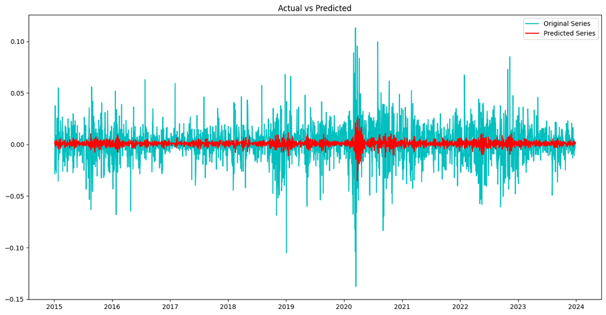

```python
# Plotting the original vs predicted series
plt.figure(figsize = (16, 8))

plt.plot(df_train['Log_Returns'], color = 'c', label = 'Original Series')

plt.plot(arima_res.fittedvalues, color='red', label = 'Predicted Series')

plt.title('Actual vs Predicted')

plt.legend()

plt.show()
```

```python
print(arima_res.summary())
```

```
                               SARIMAX Results
==============================================================================
Dep. Variable:            Log_Returns   No. Observations:                 2262
Model:                 ARIMA(9, 0, 9)   Log Likelihood                5877.247
Date:                Thu, 12 Jun 2025   AIC                         -11714.495
Time:                        22:24:31   BIC                         -11600.014
Sample:                             0   HQIC                        -11672.721
                               - 2262
Covariance Type:                  opg
==============================================================================
                 coef    std err          z      P>|z|      [0.025      0.975]
------------------------------------------------------------------------------
const          0.0009      0.000      2.115      0.034    6.55e-05       0.002
ar.L1         -0.0028      0.387     -0.007      0.994      -0.762       0.756
ar.L2         -0.0108      0.319     -0.034      0.973      -0.637       0.615
ar.L3         -0.0242      0.319     -0.076      0.940      -0.649       0.601
ar.L4         -0.0088      0.277     -0.032      0.975      -0.551       0.533
ar.L5          0.0624      0.283      0.221      0.825      -0.493       0.617
ar.L6         -0.1057      0.280     -0.378      0.706      -0.654       0.443
ar.L7          0.1681      0.282      0.596      0.551      -0.384       0.721
ar.L8         -0.1186      0.224     -0.530      0.596      -0.557       0.320
ar.L9          0.2139      0.236      0.905      0.365      -0.249       0.677
ma.L1         -0.0489      0.391     -0.125      0.900      -0.814       0.717
ma.L2         -0.0111      0.309     -0.036      0.971      -0.616       0.594
ma.L3          0.0192      0.314      0.061      0.951      -0.595       0.634
ma.L4         -0.0006      0.276     -0.002      0.998      -0.541       0.540
ma.L5         -0.0314      0.285     -0.110      0.912      -0.589       0.526
ma.L6          0.0838      0.275      0.305      0.761      -0.455       0.623
ma.L7         -0.0978      0.282     -0.347      0.729      -0.650       0.455
ma.L8          0.0542      0.234      0.231      0.817      -0.405       0.514
ma.L9         -0.1248      0.222     -0.562      0.574      -0.560       0.310
sigma2         0.0003   6.38e-06     50.848      0.000       0.000       0.000
===================================================================================
Ljung-Box (L1) (Q):                   0.03   Jarque-Bera (JB):              1652.73
Prob(Q):                              0.87   Prob(JB):                         0.00
Heteroskedasticity (H):               1.49   Skew:                            -0.30
Prob(H) (two-sided):                  0.00   Kurtosis:                         7.14
===================================================================================

Warnings:
[1] Covariance matrix calculated using the outer product of gradients (complex-step).
```

We want to make sure each term in our model is statistically significant. The null for this section is that each coefficient is NOT statistically significant. Therefore, we want each term to have a p-value of less than 0.05, so we can reject the null hypothesis with statistically significant values.

Since we have a clear sign of heteroskedasticity plus potential overfit. We will try to evaluate and model the volatility

# GARCH **Models**

GARCH stands for Generalized Autoregressive Conditional Heteroskedasticity.

It models how today's volatility depends on:

A constant level (ω),

The previous day's squared shock or residual (α₁),

The previous day's volatility (β₁).

- The primary output of a GARCH model is the conditional variance, which represents the volatility of an asset's returns. It provides valuable insights into the risk associated with an investment. A higher conditional variance indicates greater volatility, implying a higher level of risk
- GARCH models also provide information about the persistence of volatility shocks. The persistence parameter (often denoted as α + β) determines how quickly past shocks decay over time. If the persistence parameter is close to 1, it implies that volatility shocks have a long-lasting impact on future volatility. On the other hand, if it is closer to 0, volatility shocks dissipate quickly, indicating a more short-term effect.
- Significance of Parameters: If we find that certain parameters are statistically insignificant (p-value > 0.05), it implies that they do not contribute significantly to explaining volatility dynamics and can be omitted from the model. On the other hand, significant parameters (p-value < 0.05) indicate their importance in capturing volatility patterns.

```python
!pip install arch
from arch import arch_model
```

```python
residuals = arima_res.resid
```

```python
model_garch = arch_model(residuals, vol='GARCH', p=1, q=1)
results_garch = model_garch.fit()
print(results_garch.summary())
```

```
Iteration:      1,   Func. Count:      6,   Neg. LLF: 7492977324.952217
Iteration:      2,   Func. Count:     19,   Neg. LLF: 1.15275429449393e+16
Iteration:      3,   Func. Count:     31,   Neg. LLF: 180352749065306.44
Iteration:      4,   Func. Count:     46,   Neg. LLF: 39208427.43643961
Iteration:      5,   Func. Count:     58,   Neg. LLF: 1.2851868683418932e+24
Iteration:      6,   Func. Count:     73,   Neg. LLF: 30586644.91620693
Iteration:      7,   Func. Count:     85,   Neg. LLF: 341907783127142.1
Iteration:      8,   Func. Count:    100,   Neg. LLF: 1.4501478576652754e+18
Iteration:      9,   Func. Count:    112,   Neg. LLF: 538488337496669.3
Iteration:     10,   Func. Count:    126,   Neg. LLF: -6080.149300880702
Optimization terminated successfully    (Exit mode 0)
            Current function value: -6080.149294183411
            Iterations: 14
            Function evaluations: 126
            Gradient evaluations: 10
                     Constant Mean - GARCH Model Results
==============================================================================
Dep. Variable:                   None   R-squared:                       0.000
Mean Model:             Constant Mean   Adj. R-squared:                  0.000
Vol Model:                      GARCH   Log-Likelihood:                6080.15
Distribution:                  Normal   AIC:                          -12152.3
Method:            Maximum Likelihood   BIC:                          -12129.4
                                        No. Observations:                 2262
Date:                Thu, Jun 12 2025   Df Residuals:                     2261
Time:                        22:24:37   Df Model:                            1
                                 Mean Model
============================================================================
                 coef    std err          t      P>|t|      95.0% Conf. Int.
----------------------------------------------------------------------------
mu         8.1721e-04  1.328e-05     61.524      0.000 [7.912e-04,8.432e-04]
                              Volatility Model
============================================================================
                 coef    std err          t      P>|t|      95.0% Conf. Int.
----------------------------------------------------------------------------
omega      6.4837e-06  9.228e-12  7.026e+05      0.000 [6.484e-06,6.484e-06]
alpha[1]       0.1000  2.683e-02      3.728  1.932e-04   [4.742e-02,  0.153]
beta[1]        0.8800  2.389e-02     36.828 6.546e-297     [  0.833,  0.927]
============================================================================

Covariance estimator: robust
```

**Key Insights**

Mean return (μ): 0.000817 — statistically significant; small but consistent average return (log-returns).

Omega (ω): 6.48e-06 — long-term volatility component; very small and highly significant.

Alpha (α₁): 0.1000 — short-term volatility from recent shocks; statistically significant (p < 0.001).

Beta (β₁): 0.8800 — long-term volatility persistence; highly significant and dominant.

Volatility persistence (α + β): 0.9800 — very high; indicates strong volatility clustering and slow mean reversion.

Time-varying volatility: GARCH captures volatility dynamics effectively.

Distribution: Normal — may underestimate fat tails; consider Student’s t if needed.

R-squared: 0.000 — expected for GARCH; it models volatility, not returns.

All parameters significant: supports model validity.

**Checking the model performance**

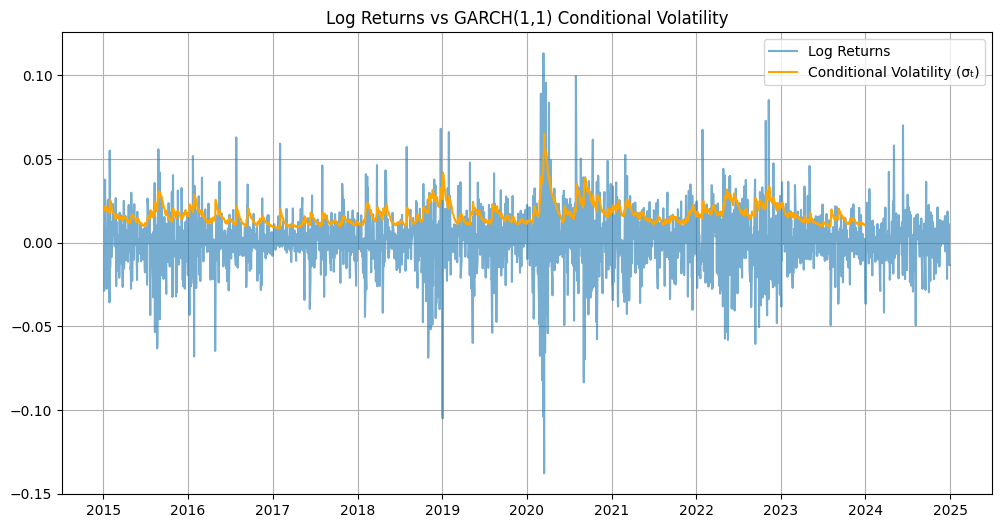

```python
#Plotting the model performance on train data
conditional_vol = results_garch.conditional_volatility
returns = data['Log_Returns']

plt.figure(figsize=(12, 6))
plt.plot(returns, label="Log Returns", alpha=0.6)
plt.plot(conditional_vol, label="Conditional Volatility (σₜ)", color="orange")
plt.title("Log Returns vs GARCH(1,1) Conditional Volatility")
plt.legend()
plt.grid(True)
plt.show()
```

```python
horizon = len(df_test['Log_Returns'])  # forecast same length as test set
forecast = results_garch.forecast(horizon=horizon)

# Get forecasted volatility (σ²) and convert to σ (std dev)
forecast_vol = forecast.variance.values[-1, :]
forecast_vol = np.sqrt(forecast_vol)

from arch import arch_model
import numpy as np

# Storage for rolling forecasts
rolling_vol = []

# Loop through test set, one-step ahead forecast at each point
for t in range(len(df_test)):
    # Expand training set one step forward each time
    y = data['Log_Returns'].iloc[:len(df_train) + t]

    # Fit the model (optional: use simpler config or pre-fit model)
    model = arch_model(y, vol='GARCH', p=1, q=1, dist='normal')
    res = model.fit(disp='off')

    # One-step-ahead forecast
    fcast = res.forecast(horizon=1)
    sigma_t = np.sqrt(fcast.variance.values[-1, 0])
    rolling_vol.append(sigma_t)

# Convert to np.array or align to df_test index
rolling_vol = np.array(rolling_vol)
```

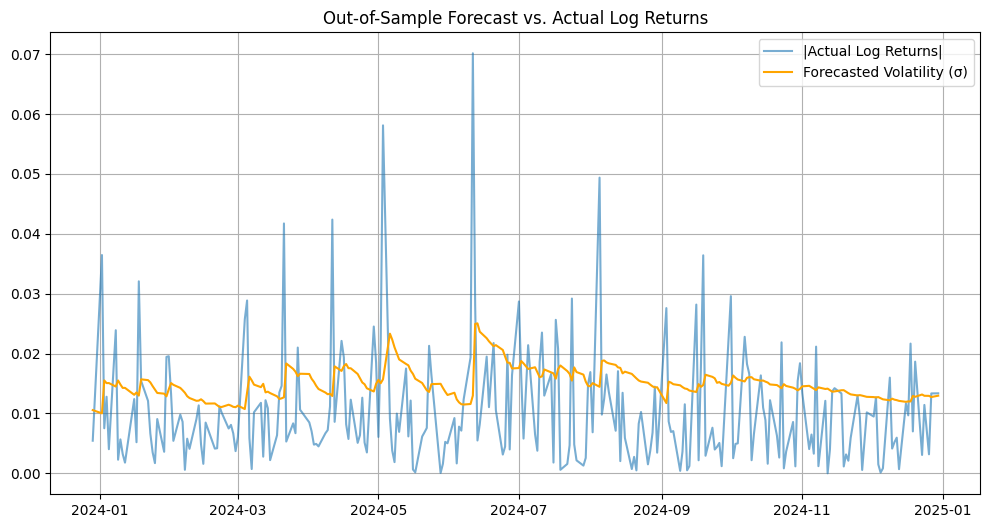

```python
plt.figure(figsize=(12, 6))
plt.plot(df_test['Log_Returns'].index, np.abs(df_test['Log_Returns']), label="|Actual Log Returns|", alpha=0.6)
plt.plot(df_test['Log_Returns'].index, rolling_vol, label="Forecasted Volatility (σ)", color="orange")
plt.title("Out-of-Sample Forecast vs. Actual Log Returns")
plt.legend()
plt.grid(True)
plt.show()
```

# Conclusions – Part 1: Log-Return & Volatility Modeling

1. Price Behavior Analysis: The analysis provides a valuable view into the behavior of asset closing prices, enabling traders to evaluate short-term dynamics and log-return patterns.
2. ARIMA Model Limitations: Although log returns are stationary, the ARIMA(9,0,9) model showed weak performance. This suggests that linear models may be insufficient and points to the potential of more advanced techniques—such as Deep Learning—to capture complex, nonlinear patterns influenced by external factors beyond just price.
3. GARCH Model Strengths & Limitations: GARCH models demonstrated strong performance in capturing time-varying volatility. They are effective in identifying risk levels over time (volatility clustering), but they do not predict direction—only magnitude—making them more useful for risk assessment than return forecasting.
4. Need for Deeper Modeling: Financial markets exhibit intricate, nonlinear behaviors. Capturing these dynamics requires further exploration of more robust models and the inclusion of macroeconomic, sentiment, or technical indicators.